# 非参第十一周作业

# 非参数统计

## 5.1

**在一个有3个主要大型商场的贸易中心，调查479个不同年龄段的人首先去3个商场中的哪一个，结果如下表所示**

| 年龄段 | 商场1 | 商场2 | 商场3 | 总和 |
| --- | --- | --- | --- | --- |
| $\le 30$ | 83 | 70 | 45 | 198 |
| $31～50$ | 91 | 86 | 15 | 192 |
| $>50$ | 41 | 38 | 10 | 89 |
| 总和 | 215 | 194 | 70 | 479 |

**$Q:$不同年龄段人对各商场的购物倾向性是否存在差异**

```r
age_mall = matrix(c(83,91,41,70,86,38,45,15,10),3,3)
age_mall
```

```
##      [,1] [,2] [,3]
## [1,]   83   70   45
## [2,]   91   86   15
## [3,]   41   38   10
```

```r
chisq.test(age_mall)
```

```
##
##  Pearson's Chi-squared test
##
## data:  age_mall
## X-squared = 18.651, df = 4, p-value = 0.0009203
```

表中输出了Pearson卡方检验的结果，自由度为$(3-1)\times (3-1)=4$，卡方值为18.651，p值为0.0009203<0.05,拒绝年龄段与商场的购物倾向性之间独立的假设，认为购物者所属的年龄段和购物者优先选择哪个商场有一定的关联。

## 5.2

**美国某年总统选举前，由社会调查总部抽查黑白种族与支持不同政党是否有关，得到下表**

| 种族 | 民主党 | 共和党 | 无党 |
| --- | --- | --- | --- |
| 白人 | 341 | 405 | 105 |
| 黑人 | 103 | 11 | 15 |

**$Q:$不同种族与所支持的政党之间是否存在独立性**

```r
elec = matrix(c(341,405,105,103,11,15),2,3,byrow = T)
elec
```

```
##      [,1] [,2] [,3]
## [1,]  341  405  105
## [2,]  103   11   15
```

```r
chisq.test(elec)
```

```
##
##  Pearson's Chi-squared test
##
## data:  elec
## X-squared = 79.431, df = 2, p-value < 2.2e-16
```

表中输出了Pearson卡方检验的结果，自由度为$(3-1)\times (2-1)=2$，卡方值为79.431，p值几乎为0,拒绝种族与支持的政党之间独立的假设，认为种族和其支持的政党之间有一定的关联。

## 5.3

**$Q:$下面是一个医学例子，研究某类肺炎患者和以前是否曾经患过该类肺炎之间的疾病继承性关系。下面是30个人按照当前患某类肺炎和曾经患某类肺炎之间的2**$\times$**2分类表**

|  | 当前有某类肺炎 | 当前没有某类肺炎 | 总和 |
| --- | --- | --- | --- |
| 以前有过某类肺炎 | 6 | 4 | 10 |
| 以前没有某类肺炎 | 1 | 19 | 20 |
| 总和 | 7 | 23 | 30 |

注意这个$2\times 2$列联表中有两个较小的值（4，1），用卡方检验会有警告，所以采用Fishier精确性检验。

```r
pneumonia = matrix(c(6,1,4,19),2,2)
pneumonia
```

```
##      [,1] [,2]
## [1,]    6    4
## [2,]    1   19
```

```r
fisher.test(pneumonia)
```

```
##
##  Fisher's Exact Test for Count Data
##
## data:  pneumonia
## p-value = 0.002122
## alternative hypothesis: true odds ratio is not equal to 1
## 95 percent confidence interval:
##     2.152514 1362.408171
## sample estimates:
## odds ratio
##    24.2696
```

Fisher精确性检验的结果p值为0.002122<0.05，认为以前是否患过某类肺炎和当前是否有某类肺炎之间有紧密的关系。

如果我们采用卡方检验会得到如下结果：

```r
chisq.test(pneumonia)
```

```
##
##  Pearson's Chi-squared test with Yates' continuity correction
##
## data:  pneumonia
## X-squared = 8.4084, df = 1, p-value = 0.003735
```

卡方检验采用了连续性修正，同样得到了拒绝原假设，认为以前是否患过某类肺炎和当前是否有某类肺炎之间有紧密的关系的结论。（但是有warning提示检验结果可能是错误的，最好还是用Fisher精确性检验）

## 5.4

**对479个不同年龄段的人调查他们对各种不同类型电视节目的喜爱情况，要求每人只能选出他们最喜欢观看的电视节目类型，结果如下表所示**

| 年龄段 | 体育类1 | 电视剧类2 | 综艺类3 | 总和 |
| --- | --- | --- | --- | --- |
| $\leqslant$ 30 | 83 | 70 | 45 | 198 |
| 31～50 | 91 | 86 | 15 | 192 |
| >50 | 41 | 38 | 10 | 89 |
| 总和 | 215 | 194 | 70 | 479 |

**$Q:$不同观众对三类节目的关注率是否一样**

```r
age_tv = matrix(c(83,91,41,70,86,38,45,15,10),3,3)
age_tv
```

```
##      [,1] [,2] [,3]
## [1,]   83   70   45
## [2,]   91   86   15
## [3,]   41   38   10
```

```r
chisq.test(age_tv)
```

```
##
##  Pearson's Chi-squared test
##
## data:  age_tv
## X-squared = 18.651, df = 4, p-value = 0.0009203
```

```r
#crosstab = c(83,91,41,70,86,38,45,15,10)
#treat = c(1,2,3,1,2,3,1,2,3)

#ridit(crosstab,treat)
```

表中输出了Pearson卡方检验的结果，自由度为$(3-1)\times (3-1)=4$，卡方值为18.651，p值为0.0009203<0.05,拒绝年龄段与电视节目的关注率之间独立的假设，认为观众所属的年龄段和观众最喜欢哪个类型的电视节目之间有一定的关联。

## 5.7

**$Q:$对三类不同学校，分别考察学生家庭经济情况与其高考成绩之间的关系，用经济状况好(A)与经济状况一般(B)对比记录其结果，如下表**

[output not shown]

**试分析学生家庭经济情况与其高考成绩之间的关系**

```r
school1 = matrix(c(43,87,65,77),2,2)
school2 = matrix(c(9,15,73,30),2,2)
school3 = matrix(c(7,18,9,11),2,2)

m = c(school1,school2,school3);x = array(m,c(2,2,3))#3所学校
x
```

```
## , , 1
##
##      [,1] [,2]
## [1,]   43   65
## [2,]   87   77
##
## , , 2
##
##      [,1] [,2]
## [1,]    9   73
## [2,]   15   30
##
## , , 3
##
##      [,1] [,2]
## [1,]    7    9
## [2,]   18   11
```

```r
mantelhaen.test(x)
```

```
##
##  Mantel-Haenszel chi-squared test with continuity correction
##
## data:  x
## Mantel-Haenszel X-squared = 11.638, df = 1, p-value = 0.0006461
## alternative hypothesis: true common odds ratio is not equal to 1
## 95 percent confidence interval:
##  0.3222519 0.7298350
## sample estimates:
## common odds ratio
##         0.4849646
```

以上得到Mantel-Haenszel检验的结果$Q_{MH}= 11.638$,p值为0.0006461<0.05，通过检验，说明学生家庭经济情况与其高考成绩之间有关系。

```r
chisq.test(school1)
```

```
##
##  Pearson's Chi-squared test with Yates' continuity correction
##
## data:  school1
## X-squared = 4.0557, df = 1, p-value = 0.04402
```

```r
fisher.test(school1)
```

```
##
##  Fisher's Exact Test for Count Data
##
## data:  school1
## p-value = 0.03555
## alternative hypothesis: true odds ratio is not equal to 1
## 95 percent confidence interval:
##  0.3468560 0.9859127
## sample estimates:
## odds ratio
##  0.5866505
```

```r
chisq.test(school2)
```

```
##
##  Pearson's Chi-squared test with Yates' continuity correction
##
## data:  school2
## X-squared = 8.0736, df = 1, p-value = 0.004491
```

```r
fisher.test(school2)
```

```
##
##  Fisher's Exact Test for Count Data
##
## data:  school2
## p-value = 0.003785
## alternative hypothesis: true odds ratio is not equal to 1
## 95 percent confidence interval:
##  0.08605749 0.68517068
## sample estimates:
## odds ratio
##  0.2496606
```

```r
chisq.test(school3)
```

```
##
##  Pearson's Chi-squared test with Yates' continuity correction
##
## data:  school3
## X-squared = 0.75768, df = 1, p-value = 0.3841
```

```r
fisher.test(school3)
```

```
##
##  Fisher's Exact Test for Count Data
##
## data:  school3
## p-value = 0.3484
## alternative hypothesis: true odds ratio is not equal to 1
## 95 percent confidence interval:
##  0.1144992 1.9443222
## sample estimates:
## odds ratio
##  0.4834632
```

## 案例分析

**一研究机构获得一组研究数据，数据内容包含1000名婴儿的出生体重和5个相关变量。使用这份数据来探究低体重出生婴儿的影响变量**

数据说明：

| 变量名 | 含义 |
| --- | --- |
| weight | 婴儿出生体重(g) |
| black | 母亲是否为黑人(1:是，0:否) |
| married | 母亲是否已婚(1:是，0:否) |
| ed.hs | 母亲的教育程度是否为高中(1:是，0:否) |
| ed.col | 母亲的教育程度是否为大学(1:是，0:否) |
| m.wtgain | 母亲怀孕期间增加的体重(磅) |
| mom.age | 母亲相对怀孕年龄（岁） |
| cigsper | 母亲怀孕期间平均每个月抽烟数量（根） |

研讨问题

1.定义低体重出生婴儿体重为2500g以下。请绘制未婚黑人母亲的婴儿出生体重经验分布的点估计和90%，95%，99%置信区间估计，并从图上观察判断婴儿低体重和母亲婚姻状况之间的关系。

2.用泊松回归模型探究黑人母亲、母亲怀孕期间增加体重与低体重婴儿之间的关系。

3.尝试对母亲的受教育程度进行分析，并将其与母亲是否已婚纳入回归模型，做进一步分析。

4.尝试使用对数线性模型进行分析，分析比较泊松回归与对数线性模型所得结果的异同。

1. 问题1：根据第一章的Dvoretzky-Kiefer-Wolfowitz不等式，可以得到：

令

$$L(x) = max\{F_n(x) - \epsilon_n,0\},U(x) = min\{F_n(x) + \epsilon_n,1\}$$

其中

$$\epsilon_n=\sqrt{\frac{1}{2n}ln\frac 2\alpha}$$
那么
$$P(L(x)\le F(x)\le U(x))\ge1-\alpha$$

根据该公式绘制未婚黑人母亲的婴儿出生体重经验分布及其置信区间估计。

```r
birthw = read.csv("birth_weight.csv",stringsAsFactors = F)
head(birthw)
```

| black | married | boy | ed.hs | ed.col | mom.age | cigsper | m.wtgain | weight |
| --- | --- | --- | --- | --- | --- | --- | --- | --- |
| 0 | 1 | 1 | 1 | 0 | -3 | 0 | -16 | 4111 |
| 0 | 1 | 0 | 0 | 1 | 1 | 0 | 2 | 3997 |
| 0 | 1 | 1 | 1 | 0 | 0 | 0 | -3 | 3572 |
| 0 | 1 | 1 | 0 | 1 | -1 | 0 | -5 | 1956 |
| 0 | 1 | 1 | 1 | 0 | -6 | 0 | -20 | 3515 |
| 0 | 1 | 0 | 0 | 1 | 3 | 0 | 0 | 3757 |

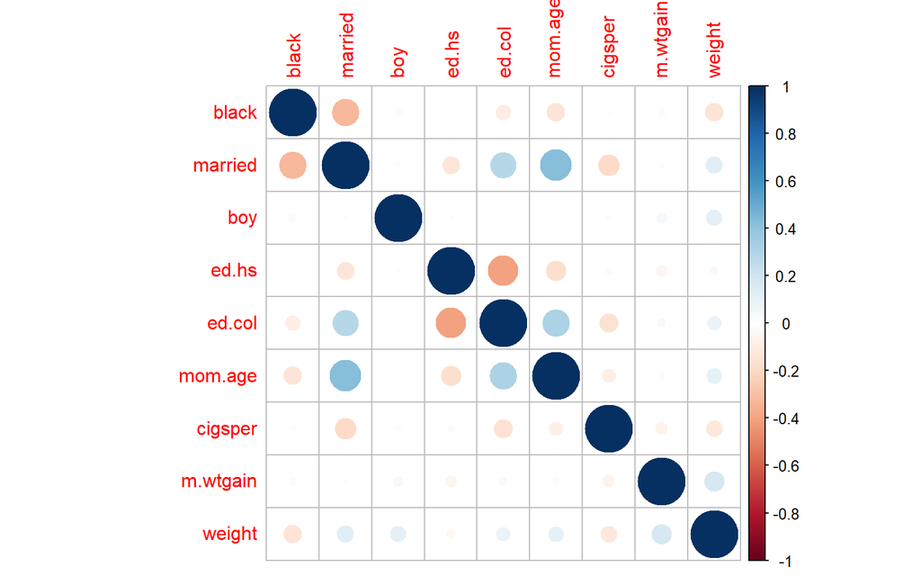

```r
#观察变量之间的相关性
corrplot(corr = cor(birthw))
```

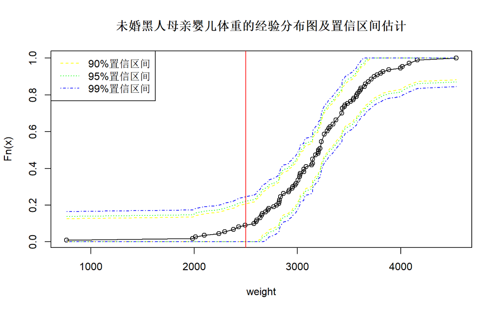

```r
#结果显示为弱相关

#黑人母亲&未婚母亲选取并排序
weight.sort = sort(birthw$weight[birthw$black==1&birthw$married==0])
plotecdf_confint = function(weight.sort,title){
  weight.rank = rank(weight.sort)#求秩
  n = length(weight.sort)
  weight.ecd = weight.rank/n#求经验分布
  #绘制经验分布函数图像
  pictitle = paste(title,
                   "母亲婴儿体重的经验分布图及置信区间估计",
                   sep = "")
  plot(weight.sort,weight.ecd,type = "o",xlab = "weight",ylab = "Fn(x)",main = pictitle)
  band = sqrt(log(2/0.1)/(2*n))#计算得到90%置信区间在各点处的上下界
  band2 = sqrt(log(2/0.05)/(2*n))#计算得到95%置信区间在各点处的上下界
  band3 = sqrt(log(2/0.01)/(2*n))#计算得到99%置信区间在各点处的上下界
  #绘制90%置信区间
  lower.9 = weight.ecd-band
  upper.9 = weight.ecd+band
  lower.9[which(lower.9<0)] = 0
  upper.9[which(upper.9>1)] = 1
  lines(weight.sort,lower.9,lty = 2,col = "yellow")
  lines(weight.sort,upper.9,lty = 2,col = "yellow")
  #绘制95%置信区间
  lower.95 = weight.ecd-band2
  upper.95 = weight.ecd+band2
  lower.95[which(lower.95<0)] = 0
  upper.95[which(upper.95>1)] = 1
  lines(weight.sort,lower.95,lty = 3,col = "green")
  lines(weight.sort,upper.95,lty = 3,col = "green")
  #绘制99%置信区间
  lower.99 = weight.ecd-band3
  upper.99 = weight.ecd+band3
  lower.99[which(lower.99<0)] = 0
  upper.99[which(upper.99>1)] = 1
  lines(weight.sort,lower.99,lty = 4,col = "blue")
  lines(weight.sort,upper.99,lty = 4,col = "blue")
  abline(v = 2500,col = "red")#低体重界限
  #图例添加
  legend("topleft",legend = c("90%置信区间","95%置信区间","99%置信区间"),col = c("yellow","green","blue"),lty = c(2,3,4))
}

plotecdf_confint(weight.sort,"未婚黑人")
```

图中红色竖线为判定婴儿是否为低体重的界限（2500g），红线左边为低体重。可以看到在90%、95%、99%的置信度下，未婚黑人母亲的婴儿的低体重率的上限分别约为20%、22.5%、25%,与世界平均水平——2019年为14.3%（参考自https://news.un.org/zh/story/2019/05/1034491）——相比这个比率是偏高的；从整体上看，婴儿的体重主要分布在2500g到4000g之间，但仍然存在一定数量的极小值；从体重角度看，未婚黑人母亲的婴儿健康状况较为堪忧，且整体方差较大。

接下来绘制已婚黑人母亲的婴儿出生体重经验分布及其置信区间估计。

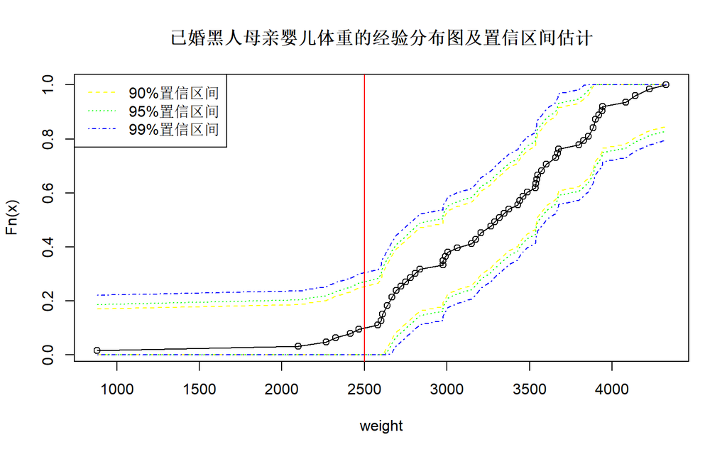

```r
weight.sort = sort(birthw$weight[birthw$black==1&birthw$married==1])#已婚黑人母亲
plotecdf_confint(weight.sort,"已婚黑人")
```

图中红色竖线为判定婴儿是否为低体重的界限（2500g），红线左边为低体重。可以看到在90%、95%、99%的置信度下，已婚黑人母亲的婴儿的低体重率的上限分别约为25%、27.5%、30%,与世界平均水平相比这个比率是偏高的；从整体上看，婴儿的体重主要分布在2500g到4000g之间，但仍然存在一定数量的极小值；从体重角度看，已婚黑人母亲的婴儿健康状况较为堪忧，且整体方差很大。

接下来绘制已婚白人母亲的婴儿出生体重经验分布及其置信区间估计。

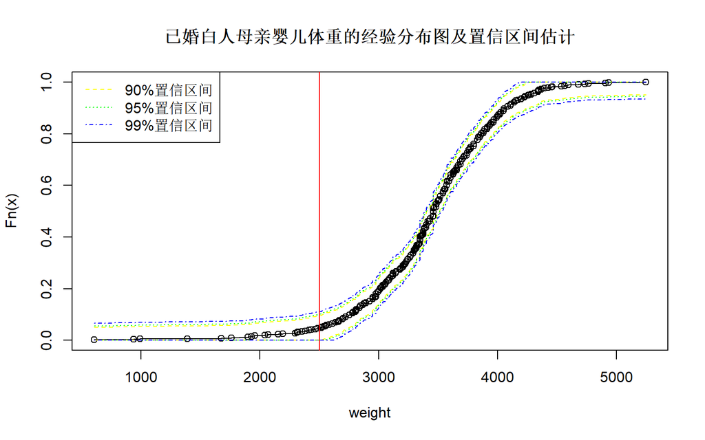

```r
weight.sort = sort(birthw$weight[birthw$black==0&birthw$married==1])#已婚白人母亲
plotecdf_confint(weight.sort,"已婚白人")
```

接下来绘制未婚白人母亲的婴儿出生体重经验分布及其置信区间估计。

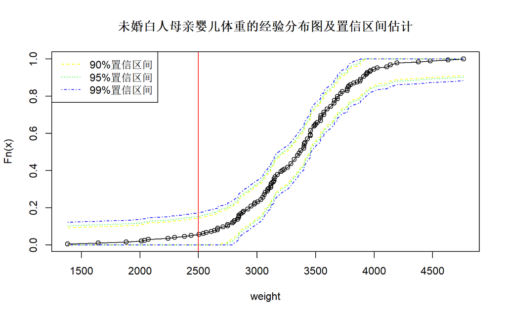

```r
weight.sort = sort(birthw$weight[birthw$black==0&birthw$married==0])#未婚白人母亲
plotecdf_confint(weight.sort,"未婚白人")
```

问题2：

记$Y$表示婴儿低体重事件发生的频数，$Y$服从泊松分布，$Y=y,y=0,1,2,...$发生的概率可以表示为
$$f(y;\mu)=\frac{\mu^y e^{-\mu}}{y!},y=\{0,1,2,...\}.$$
则$E(Y)=\mu,Var(Y)=\mu$,$\mu$是事件的平均发生数。

令$Y_1,Y_2,...,Y_N$为iid的随机变量，$Y_i$表示在暴露$exposure_i$下事件发生次数。

$$E(Y_i)=\mu_i=exposure_i\eta_i$$
其中$\eta_i$为泊松回归模型的系统成分——即各个解释变量的线性组合，$\eta_i=e^{X_i\beta}$

对这个等式取对数可以得到$log(\mu_i)=log(exposure_i)+log(\eta_i)=log(exposure_i)+X_i\beta$

我们关心的是婴儿低体重率，即$\frac{\mu_i }{exposure_i}$（其中$exposure_i$暴露，为已知数据(offset项)，在本题中为婴儿总数）。

由于$log(\frac{\mu_i }{exposure_i})=log(\mu_i)-log(exposure_i)=log(\eta_i)=X_i\beta$

所以我们建立如下的泊松回归模型：
$$log(\mu_i)=log(exposure_i)+X_i\beta$$

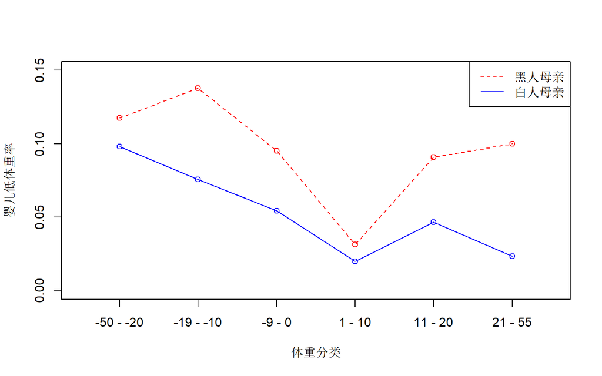

```r
#分组
birthw$classified[birthw$m.wtgain>-50 & birthw$m.wtgain<=-20] <- "-50 - -20"
birthw$classified[birthw$m.wtgain>=-19 & birthw$m.wtgain<=-10] <- "-19 - -10"
birthw$classified[birthw$m.wtgain>=-9 & birthw$m.wtgain<=0] <- "-9 - 0"
birthw$classified[birthw$m.wtgain>=1 & birthw$m.wtgain<=10] <- "1 - 10"
birthw$classified[birthw$m.wtgain>=11 & birthw$m.wtgain<=20] <- "11 - 20"
birthw$classified[birthw$m.wtgain>=21 & birthw$m.wtgain<=55] <- "21 - 55"
#因子化
birthw$classified <- factor(birthw$classified,levels =
c("-50 - -20","-19 - -10", "-9 - 0","1 - 10","11 - 20","21 - 55"))
birthw$LowAndBlack <- 0
birthw$LowAndBlack[birthw$black==1&birthw$weight<2500] <- 1#黑人母亲&婴儿低体重
birthw$LowAndWhite <- 0
birthw$LowAndWhite[birthw$black==0&birthw$weight<2500] <- 1#白人母亲&婴儿低体重
#分类汇总
birthw_new <- group_by(birthw,classified)#按照怀孕期间母亲增重分组进行分类汇总
#分类汇总为区组
block <- summarise(birthw_new,black = sum(black),black_low =
sum(LowAndBlack),white=n()-sum(black),white_low=sum(LowAndWhite))

#block

low_bw_ratio = data.frame(block)
low_bw_ratio$lbwrw = low_bw_ratio$white_low/low_bw_ratio$white
low_bw_ratio$lbwrb = low_bw_ratio$black_low/low_bw_ratio$black

plot(low_bw_ratio$classified,rep(-1,length(low_bw_ratio$classified)),ylim = c(0,0.15),xlab = "体重分类",ylab = "婴儿低体重率")
lines(low_bw_ratio$classified,low_bw_ratio$lbwrb,
      type = "o",lty = 2, col = "red")
lines(low_bw_ratio$classified,low_bw_ratio$lbwrw,
      type = "o",col = "blue")
legend("topright",legend = c("黑人母亲","白人母亲"),
       col = c("red","blue"),lty = c(2,1))
```

```r
#数据框
dat <- data.frame(loss_weight=rep(block$classified,2),
                  black=c(rep(1,6),rep(0,6)),
                  total_number =c(block$black,block$white),
                  weight_low = c(block$black_low,block$white_low))

dat$black <- as.factor(dat$black)#因子化

#dat

#泊松回归
res.weight <- glm(weight_low ~loss_weight+black+offset(log(total_number)),
                  data = dat,family = poisson)

summary(res.weight)
```

```
##
## Call:
## glm(formula = weight_low ~ loss_weight + black + offset(log(total_number)),
##     family = poisson, data = dat)
##
## Deviance Residuals:
##        1         2         3         4         5         6         7         8
## -0.37678   0.05534  -0.00003  -0.08945   0.10349   0.50079   0.27073  -0.03640
##        9        10        11        12
##  0.00002   0.04146  -0.07058  -0.37314
##
## Coefficients:
##                      Estimate Std. Error z value Pr(>|z|)
## (Intercept)           -2.4460     0.3937  -6.213 5.19e-10 ***
## loss_weight-19 - -10  -0.1238     0.4693  -0.264   0.7919
## loss_weight-9 - 0     -0.4664     0.4371  -1.067   0.2860
## loss_weight1 - 10     -1.4926     0.5591  -2.670   0.0076 **
## loss_weight11 - 20    -0.5870     0.5566  -1.055   0.2916
## loss_weight21 - 55    -0.9639     0.8021  -1.202   0.2295
## black1                 0.5610     0.2984   1.880   0.0601 .
## ---
## Signif. codes:  0 '***' 0.001 '**' 0.01 '*' 0.05 '.' 0.1 ' ' 1
##
## (Dispersion parameter for poisson family taken to be 1)
##
##     Null deviance: 16.95811  on 11  degrees of freedom
## Residual deviance:  0.63508  on  5  degrees of freedom
## AIC: 51.623
##
## Number of Fisher Scoring iterations: 4
```

问题3：

```r
birthw$edu[birthw$ed.col==1] = "college"
birthw$edu[birthw$ed.hs ==1] = "high-school"
birthw$edu[birthw$ed.col==0&birthw$ed.hs==0] = "neither"
birthw$edu = factor(birthw$edu,levels = c("college","high-school","neither"))
birthw$low_weight = 0
birthw$low_weight[birthw$weight<2500]=1

birthw2 = group_by(birthw,classified,edu,married,black)
block2 <- summarise(birthw2,totalnum = n(),LowWeightBaby = sum(low_weight))
block2#分类汇总后的数据情况
```

| classified | edu | married | black | totalnum | LowWeightBaby |
| --- | --- | --- | --- | --- | --- |
| -50 - -20 | college | 1 | 0 | 6 | 1 |
| -50 - -20 | college | 1 | 1 | 2 | 0 |
| -50 - -20 | high-school | 0 | 0 | 4 | 0 |
| -50 - -20 | high-school | 0 | 1 | 6 | 1 |
| -50 - -20 | high-school | 1 | 0 | 18 | 1 |
| -50 - -20 | high-school | 1 | 1 | 1 | 0 |
| -50 - -20 | neither | 0 | 0 | 10 | 1 |
| -50 - -20 | neither | 0 | 1 | 6 | 1 |
| -50 - -20 | neither | 1 | 0 | 13 | 2 |
| -50 - -20 | neither | 1 | 1 | 2 | 0 |
| -19 - -10 | college | 0 | 0 | 1 | 1 |
| -19 - -10 | college | 0 | 1 | 1 | 0 |
| -19 - -10 | college | 1 | 0 | 25 | 3 |
| -19 - -10 | college | 1 | 1 | 3 | 1 |
| -19 - -10 | high-school | 0 | 0 | 16 | 0 |
| -19 - -10 | high-school | 0 | 1 | 6 | 0 |
| -19 - -10 | high-school | 1 | 0 | 34 | 1 |
| -19 - -10 | high-school | 1 | 1 | 4 | 1 |
| -19 - -10 | neither | 0 | 0 | 14 | 2 |
| -19 - -10 | neither | 0 | 1 | 10 | 1 |
| -19 - -10 | neither | 1 | 0 | 29 | 2 |
| -19 - -10 | neither | 1 | 1 | 5 | 1 |
| -9 - 0 | college | 0 | 0 | 3 | 0 |
| -9 - 0 | college | 0 | 1 | 2 | 1 |
| -9 - 0 | college | 1 | 0 | 68 | 5 |
| -9 - 0 | college | 1 | 1 | 8 | 0 |
| -9 - 0 | high-school | 0 | 0 | 28 | 1 |
| -9 - 0 | high-school | 0 | 1 | 17 | 1 |
| -9 - 0 | high-school | 1 | 0 | 72 | 5 |
| -9 - 0 | high-school | 1 | 1 | 6 | 0 |
| -9 - 0 | neither | 0 | 0 | 28 | 0 |
| -9 - 0 | neither | 0 | 1 | 24 | 2 |
| -9 - 0 | neither | 1 | 0 | 77 | 4 |
| -9 - 0 | neither | 1 | 1 | 6 | 2 |
| 1 - 10 | college | 0 | 0 | 6 | 1 |
| 1 - 10 | college | 1 | 0 | 73 | 0 |
| 1 - 10 | college | 1 | 1 | 5 | 0 |
| 1 - 10 | high-school | 0 | 0 | 23 | 2 |
| 1 - 10 | high-school | 0 | 1 | 9 | 0 |
| 1 - 10 | high-school | 1 | 0 | 47 | 1 |
| 1 - 10 | high-school | 1 | 1 | 3 | 0 |
| 1 - 10 | neither | 0 | 0 | 29 | 0 |
| 1 - 10 | neither | 0 | 1 | 9 | 1 |
| 1 - 10 | neither | 1 | 0 | 74 | 1 |
| 1 - 10 | neither | 1 | 1 | 6 | 0 |
| 11 - 20 | college | 1 | 0 | 22 | 0 |
| 11 - 20 | college | 1 | 1 | 2 | 0 |
| 11 - 20 | high-school | 0 | 0 | 15 | 1 |
| 11 - 20 | high-school | 0 | 1 | 4 | 0 |
| 11 - 20 | high-school | 1 | 0 | 16 | 0 |
| 11 - 20 | high-school | 1 | 1 | 2 | 1 |
| 11 - 20 | neither | 0 | 0 | 8 | 1 |
| 11 - 20 | neither | 0 | 1 | 11 | 1 |
| 11 - 20 | neither | 1 | 0 | 25 | 2 |
| 11 - 20 | neither | 1 | 1 | 3 | 0 |
| 21 - 55 | college | 0 | 1 | 2 | 0 |
| 21 - 55 | college | 1 | 0 | 6 | 0 |
| 21 - 55 | high-school | 0 | 0 | 6 | 0 |
| 21 - 55 | high-school | 0 | 1 | 1 | 1 |
| 21 - 55 | high-school | 1 | 0 | 7 | 0 |
| 21 - 55 | high-school | 1 | 1 | 3 | 0 |
| 21 - 55 | neither | 0 | 0 | 3 | 0 |
| 21 - 55 | neither | 0 | 1 | 2 | 0 |
| 21 - 55 | neither | 1 | 0 | 21 | 1 |
| 21 - 55 | neither | 1 | 1 | 2 | 0 |

```r
#dat2 = data.frame(loss_weight=rep(block2$classified,12),
#                  black=c(rep(1,36),rep(0,36)),
#                  edu=c(rep(block2$edu,24)),
#                  marry=c(rep(c(1,0),36)),
#                  total_number =c(block2$black,block2$white),
#                  weight_low = c(block2$black_low,block2$white_low))
#人种黑白2，教育程度大学、高中、均不3种，婚姻两种，相乘12种情况，所以loss_weight重复12次和他们匹配
#lossweight6种情况，受教育程度三种，婚姻两种，相乘36种，所以black重复各36次
#lossweight6种情况，人种2种，婚姻两种，共计24种，所以edu重复24次
#lossweight6种情况，受教育程度三种，人种2种，共计36种，婚姻36次

#这个方法不可行——不太智能，因为这个时候marry的情况并不是都有的，比如具有大学学历的里面只有已婚白人而没有其他情况，导致rep的想法无法实施

res.weight2 <- glm(LowWeightBaby ~ classified+black+edu
                   +married
                   +offset(log(totalnum)),
                   data = block2,family = poisson)
summary(res.weight2)
```

```
##
## Call:
## glm(formula = LowWeightBaby ~ classified + black + edu + married +
##     offset(log(totalnum)), family = poisson, data = block2)
##
## Deviance Residuals:
##     Min       1Q   Median       3Q      Max
## -1.8520  -0.6732  -0.3990   0.4654   2.0219
##
## Coefficients:
##                     Estimate Std. Error z value Pr(>|z|)
## (Intercept)         -2.21289    0.56960  -3.885 0.000102 ***
## classified-19 - -10 -0.13335    0.47008  -0.284 0.776663
## classified-9 - 0    -0.48668    0.43887  -1.109 0.267454
## classified1 - 10    -1.53181    0.56217  -2.725 0.006434 **
## classified11 - 20   -0.61421    0.55756  -1.102 0.270637
## classified21 - 55   -0.97999    0.80318  -1.220 0.222417
## black                0.53174    0.32397   1.641 0.100732
## eduhigh-school      -0.33283    0.38620  -0.862 0.388788
## eduneither          -0.09323    0.36233  -0.257 0.796937
## married             -0.08336    0.32097  -0.260 0.795089
## ---
## Signif. codes:  0 '***' 0.001 '**' 0.01 '*' 0.05 '.' 0.1 ' ' 1
##
## (Dispersion parameter for poisson family taken to be 1)
##
##     Null deviance: 68.885  on 64  degrees of freedom
## Residual deviance: 51.634  on 55  degrees of freedom
## AIC: 151.15
##
## Number of Fisher Scoring iterations: 6
```

加入教育程度和婚姻状况变量之后，模型的AIC变大了很多，而且通过检验我们发现，整体系数显著性不高。加入的教育程度、婚姻状况的显著性水平都很差。

因此我们不考虑这两个分类变量，而将吸烟状况和怀孕年龄纳入模型。

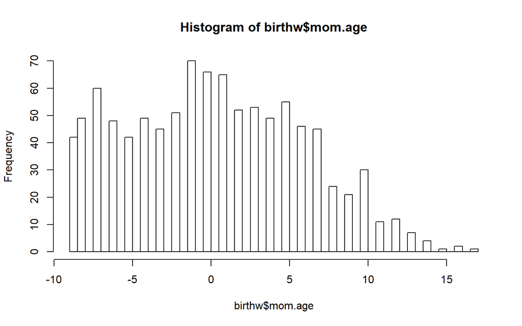

```r
hist(birthw$mom.age,breaks = 40)
```

```r
birthw$momage[birthw$mom.age<=-5] = "young"
birthw$momage[birthw$mom.age>-5&birthw$mom.age<5] = "right_age"
birthw$momage[birthw$mom.age>=5] = "elderly"
birthw$momage = factor(birthw$momage,levels = c("young","right_age","elderly"))

#birthw$docig[birthw$cigsper==0] = "never"
#birthw$docig[birthw$cigsper<=6&birthw$cigsper>0] = "seldom"  #一个月30天*20%
#birthw$docig[birthw$cigsper<=12&birthw$cigsper>6] = "often"  #40%
#birthw$docig[birthw$cigsper<=30&birthw$cigsper>12] = "usual"  #一个月30天*60%
#birthw$docig[birthw$cigsper>30] = "always"
#birthw$docig = factor(birthw$docig,
#                      levels = c("never","seldom","often","usual","always"))

## Coefficients:
##                     Estimate Std. Error z value Pr(>|z|)
## docigseldom            0.76340    0.47245   1.616  0.10613
## docigoften            -0.95085    1.01242  -0.939  0.34763
## docigusual             0.88360    0.53486   1.652  0.09853 .
## docigalways          -15.38600 2719.98475  -0.006  0.99549
#AIC: 95.571



#试了各种分类标准，选择整体显著性水平最高的这一组
#没有什么科学依据，就是瞎分
birthw$docig[birthw$cigsper==0] = "never"
birthw$docig[birthw$cigsper<=6&birthw$cigsper>0] = "seldom"  #一个月30天*20%
birthw$docig[birthw$cigsper<=12&birthw$cigsper>6] = "often"  #40%
birthw$docig[birthw$cigsper>12] = "usual"  #一个月30天*60%
birthw$docig = factor(birthw$docig,
                      levels = c("never","seldom","often","usual"))

## Coefficients:
##                     Estimate Std. Error z value Pr(>|z|)
## docigseldom          0.76184    0.47244   1.613   0.1068
## docigoften          -0.95580    1.01230  -0.944   0.3451
## docigusual           0.74690    0.53299   1.401   0.1611
## AIC: 94.369



#birthw$docig[birthw$cigsper==0] = "never"
#birthw$docig[birthw$cigsper<=6&birthw$cigsper>0] = "seldom"  #一个月30天*20%
#birthw$docig[birthw$cigsper>6] = "often"  #40%
#birthw$docig = factor(birthw$docig,
#                      levels = c("never","seldom","often"))

## Coefficients:
##                     Estimate Std. Error z value Pr(>|z|)
## docigseldom           0.7644     0.4724   1.618  0.10563
## docigoften            0.0989     0.4760   0.208  0.83541
## ---
## Signif. codes:  0 '***' 0.001 '**' 0.01 '*' 0.05 '.' 0.1 ' ' 1
##
## (Dispersion parameter for poisson family taken to be 1)
##
##     Null deviance: 36.818  on 31  degrees of freedom
## Residual deviance: 18.341  on 23  degrees of freedom
## AIC: 87.91


#birthw$docig[birthw$cigsper==0] = "never"
#birthw$docig[birthw$cigsper>0] = "do"
#birthw$docig = factor(birthw$docig,
#                      levels = c("never","do"))

## Coefficients:
##                     Estimate Std. Error z value Pr(>|z|)
## docigdo              0.38113    0.35244   1.081  0.27952
## AIC: 74.54

block3 = summarise(group_by(birthw,classified,black,docig,momage),
                   totalnum=n(),LowWeightBaby = sum(low_weight))
#block3

res.weight3 <- glm(LowWeightBaby ~ classified+black+docig+momage
                   +offset(log(totalnum)),data = block3,family = poisson)
summary(res.weight3)
```

```
##
## Call:
## glm(formula = LowWeightBaby ~ classified + black + docig + momage +
##     offset(log(totalnum)), family = poisson, data = block3)
##
## Deviance Residuals:
##     Min       1Q   Median       3Q      Max
## -1.7584  -0.5592  -0.3341   0.1029   2.3037
##
## Coefficients:
##                     Estimate Std. Error z value Pr(>|z|)
## (Intercept)         -3.13540    0.53830  -5.825 5.72e-09 ***
## classified-19 - -10 -0.06513    0.47765  -0.136   0.8915
## classified-9 - 0    -0.36553    0.44459  -0.822   0.4110
## classified1 - 10    -1.41959    0.56303  -2.521   0.0117 *
## classified11 - 20   -0.53748    0.56178  -0.957   0.3387
## classified21 - 55   -0.86708    0.80551  -1.076   0.2817
## black                0.67847    0.30492   2.225   0.0261 *
## docigseldom          0.84627    0.47566   1.779   0.0752 .
## docigoften          -0.87555    1.01290  -0.864   0.3874
## docigusual           0.79943    0.53476   1.495   0.1349
## momageright_age      0.74368    0.38046   1.955   0.0506 .
## momageelderly        0.43189    0.44986   0.960   0.3370
## ---
## Signif. codes:  0 '***' 0.001 '**' 0.01 '*' 0.05 '.' 0.1 ' ' 1
##
## (Dispersion parameter for poisson family taken to be 1)
##
##     Null deviance: 77.517  on 92  degrees of freedom
## Residual deviance: 51.610  on 81  degrees of freedom
## AIC: 148.01
##
## Number of Fisher Scoring iterations: 6
```

模型整体系数较为显著。

哑变量black的估计值为0.67847，即相比于白人母亲，黑人母亲婴儿低体重率的比率比的估计值为$e^(0.67847)\approx1.97086$，且该估计值在5%的显著性水平下显著，也就是说相比于白人母亲，黑人母亲有近两倍的概率生出低体重婴儿。

哑变量docigseldom的估计值为0.84627，即相比于从不抽烟的母亲，偶尔抽烟的母亲婴儿低体重率的比率比的估计值为$e^{0.84627}\approx2.330936$，且该估计值在10%的显著性水平下显著，也就是说相比于从不抽烟的母亲，偶尔抽烟的母亲有超过2倍的概率生出低体重婴儿。

哑变量momageright_age的估计值为0.74368，即相比于低龄母亲，适龄母亲的婴儿低体重率的比率比的估计值为$e^{0.74368}\approx 2.103663$，且该估计值在10%的显著性水平下显著，也就是说相比于低龄母亲，适龄母亲有约2倍的概率生出低体重婴儿。——这个结论可能是由于样本本身并不是来自随机抽样的，而是基于方便原则得到的一个有偏样本。

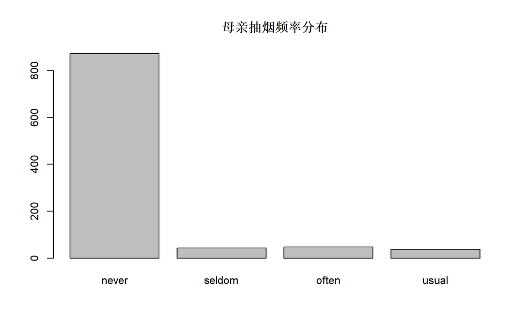

```r
plot(birthw$docig,main = "母亲抽烟频率分布")
```

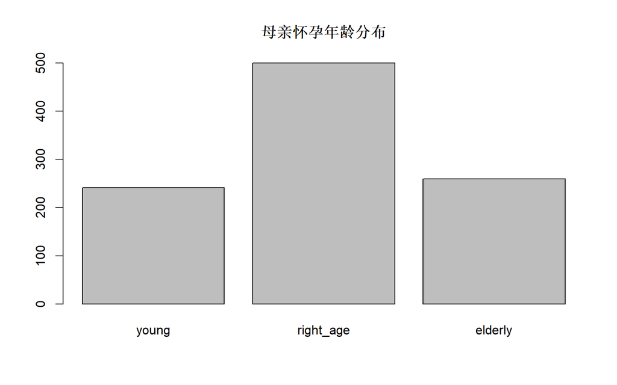

```r
plot(birthw$momage,main = "母亲怀孕年龄分布")
```

由图中可以看出，绝大多数是从不抽烟的母亲——占比超过80%。这样的样本是不均匀的（左偏严重），而我们并没有对占比较少的吸烟群体进行很好的分类，也没有对整个样本进行加权处理，所以导致我们训练的模型可能存在对不吸烟母亲群体的过拟合；而母亲怀孕年龄分布是一个对称分布，而且峰不是很高，很妙。

问题4：

试试这个类泊松回归（quasipoisson）

```r
res.weight1 = glm(weight_low ~loss_weight+black+offset(log(total_number)),
                  data = dat,family = quasipoisson(link = log))

summary(res.weight1)
```

```
##
## Call:
## glm(formula = weight_low ~ loss_weight + black + offset(log(total_number)),
##     family = quasipoisson(link = log), data = dat)
##
## Deviance Residuals:
##        1         2         3         4         5         6         7         8
## -0.37678   0.05534  -0.00003  -0.08945   0.10349   0.50079   0.27073  -0.03640
##        9        10        11        12
##  0.00002   0.04146  -0.07058  -0.37314
##
## Coefficients:
##                      Estimate Std. Error t value Pr(>|t|)
## (Intercept)           -2.4460     0.1439 -17.002 1.29e-05 ***
## loss_weight-19 - -10  -0.1238     0.1715  -0.722 0.502588
## loss_weight-9 - 0     -0.4664     0.1598  -2.920 0.033033 *
## loss_weight1 - 10     -1.4926     0.2043  -7.305 0.000753 ***
## loss_weight11 - 20    -0.5870     0.2034  -2.886 0.034358 *
## loss_weight21 - 55    -0.9639     0.2931  -3.288 0.021754 *
## black1                 0.5610     0.1091   5.144 0.003634 **
## ---
## Signif. codes:  0 '***' 0.001 '**' 0.01 '*' 0.05 '.' 0.1 ' ' 1
##
## (Dispersion parameter for quasipoisson family taken to be 0.1335557)
##
##     Null deviance: 16.95811  on 11  degrees of freedom
## Residual deviance:  0.63508  on  5  degrees of freedom
## AIC: NA
##
## Number of Fisher Scoring iterations: 4
```

```r
res.weight4 = glm(LowWeightBaby ~ classified+black+docig+momage
                   +offset(log(totalnum)),data = block3,
                  family = quasipoisson(link = log))
summary(res.weight4)
```

```
##
## Call:
## glm(formula = LowWeightBaby ~ classified + black + docig + momage +
##     offset(log(totalnum)), family = quasipoisson(link = log),
##     data = block3)
##
## Deviance Residuals:
##     Min       1Q   Median       3Q      Max
## -1.7584  -0.5592  -0.3341   0.1029   2.3037
##
## Coefficients:
##                     Estimate Std. Error t value Pr(>|t|)
## (Intercept)         -3.13540    0.55273  -5.673 2.11e-07 ***
## classified-19 - -10 -0.06513    0.49045  -0.133   0.8947
## classified-9 - 0    -0.36553    0.45651  -0.801   0.4256
## classified1 - 10    -1.41959    0.57811  -2.456   0.0162 *
## classified11 - 20   -0.53748    0.57684  -0.932   0.3542
## classified21 - 55   -0.86708    0.82710  -1.048   0.2976
## black                0.67847    0.31309   2.167   0.0332 *
## docigseldom          0.84627    0.48841   1.733   0.0870 .
## docigoften          -0.87555    1.04004  -0.842   0.4024
## docigusual           0.79943    0.54909   1.456   0.1493
## momageright_age      0.74368    0.39066   1.904   0.0605 .
## momageelderly        0.43189    0.46192   0.935   0.3526
## ---
## Signif. codes:  0 '***' 0.001 '**' 0.01 '*' 0.05 '.' 0.1 ' ' 1
##
## (Dispersion parameter for quasipoisson family taken to be 1.054313)
##
##     Null deviance: 77.517  on 92  degrees of freedom
## Residual deviance: 51.610  on 81  degrees of freedom
## AIC: NA
##
## Number of Fisher Scoring iterations: 6
```

原模型改成了对数线性模型中的类泊松回归之后，结果模型整体的显著性大幅提高——除了哑变量loss_weight-19 - -10 外全部显著了。更有力地支持了，孕期增重1-10磅是防止婴儿低体重率的最好的孕妇体重管理方式。而且人种直接的低体重率差异也在1%的显著性水平下显著了。 加入新变量的模型使用类泊松回归的结果和泊松回归差不多。 总的来说效果确实比泊松回归要好一点。

使用对数线性模型进行对比。（新教材191页，“单元格中的 频数服从多项分布，此时拟合的就是对数线性模型。） 及我们假定Y服从的分布不再是poisson而是多项分布，这个时候我们应该使用多分类logistic回归模型——一个方法是nnet里面的multinom函数，缺点是只输出系数，诊断需要手动进行；另一个方法是mlogit包里的mlogit函数，缺点是整不明白咋使用。

```r
res.weight5 = multinom(log(weight_low) ~loss_weight+black+log(total_number),
                  data = dat)
summary(res.weight5)#这个包的输出结果没有进行检验，然后一大坨系数完全看不懂
```

```
## Call:
## multinom(formula = log(weight_low) ~ loss_weight + black + log(total_number),
##     data = dat)
##
## Coefficients:
##                   (Intercept) loss_weight-19 - -10 loss_weight-9 - 0
## 0.693147180559945   10.733280           -11.315615        -10.175313
## 1.38629436111989    -1.204949            30.596843        -13.443104
## 1.6094379124341    -10.203974           -13.012777        -14.406269
## 1.79175946922805   -10.691129            -4.223381         37.540925
## 2.19722457733622   -12.759445            34.868611         -4.693944
## 2.70805020110221   -18.486438            -7.385899         34.383334
##                   loss_weight1 - 10 loss_weight11 - 20 loss_weight21 - 55
## 0.693147180559945         -22.91707          33.165223          -41.99463
## 1.38629436111989          -14.98891          32.825253          -15.85318
## 1.6094379124341             7.99960         -17.931935          -31.82393
## 1.79175946922805          -11.35401          -4.156040          -12.73819
## 2.19722457733622           -5.07656          -6.289153          -16.46798
## 2.70805020110221           -7.52270          -8.060285          -14.75689
##                       black1 log(total_number)
## 0.693147180559945  36.802134        -10.624887
## 1.38629436111989   -1.113646         -2.335651
## 1.6094379124341   -42.796800          5.827029
## 1.79175946922805    3.239403         -4.887423
## 2.19722457733622  -27.624575          2.917417
## 2.70805020110221  -24.481486          1.578834
##
## Std. Errors:
##                   (Intercept) loss_weight-19 - -10 loss_weight-9 - 0
## 0.693147180559945   7333.9911         3.700915e+04      3.644550e+04
## 1.38629436111989   25244.9508         6.742858e+04      7.956151e-01
## 1.6094379124341    43252.5365         3.449215e+01      1.001358e+05
## 1.79175946922805   13373.9469         8.835298e-08      1.335793e+04
## 2.19722457733622   29566.4882         5.640370e+04      2.251629e+04
## 2.70805020110221     911.3277         9.362709e-09      4.601060e+04
##                   loss_weight1 - 10 loss_weight11 - 20 loss_weight21 - 55
## 0.693147180559945      1.823624e+04       9.286240e+04        20312.92456
## 1.38629436111989       1.624270e+04       1.113267e+05       103251.54841
## 1.6094379124341        1.212126e+05       1.252128e+05        23333.73435
## 1.79175946922805       1.407076e-02       1.717511e-10           16.00183
## 2.19722457733622       5.887052e+01       5.723833e+02         9352.99947
## 2.70805020110221       3.091348e-05       6.903388e-03         4051.98546
##                      black1 log(total_number)
## 0.693147180559945  72896.25         27468.733
## 1.38629436111989   35336.96         20268.045
## 1.6094379124341   120836.64         11000.846
## 1.79175946922805   66016.16         22385.976
## 2.19722457733622   50916.30          7524.206
## 2.70805020110221   73916.25         29050.440
##
## Residual Deviance: 0.0001387091
## AIC: 96.00014
```

```r
#好像可以手动检验

#佛了，mlogit不会

#block3
#H = dfidx(block3,idx=c("classified","black","docig","momage"))
#res.weight5 = mnlogit(LowWeightBaby ~totalnum+black+classified,
#                  data = H)
#summary(res.weight5)
```